# Reglas de asociación y detección de anomalías: Práctica final

Jun De Wu

20/05/2021

Empezaremos por cargar todos los paquetes que necesitaremos en el trabajo.

```r
require(XML)
require(arules)
require(arulesViz)
require(tidyverse)
require(plyr)
require(tidytext)
require(tm)
require(qdapRegex)
require(splitstackshape)
require(data.table)
require(fastDummies)
require(tidyr)
require(ggcorrplot)
require(GGally)
require(factoextra)
require(dbscan)
require(mclust)
```

# 1 Reglas de asociación: Recetas de cocina

## 1.1 Limpieza de los datos

El archivo que tenemos está en formato `xml`, con lo cual lo leeremos con la función `xmlToList` del paquete `XML`.

```r
raw_data <- xmlParse("recipeBaseCompulsory_clean.xml")
xml_data <- xmlToList(raw_data)
dataset <- ldply(xml_data, data.frame)
```

El archivo nos proporciona el título de las recetas, los pasos a seguir y los ingredientes, pero a la práctica solo necesitaremos los ingredientes para encontrar reglas de asociación y utilizaremos los títulos para filtrar las recetas que sean de pescado o picantes.

Utilizaremos los paquetes `tidytext` y `tm` para hacer text mining de los datos y hacer limpieza. Empezaremos por quitar símbolos que no nos interese y todo el texto que haya después de una “,”, “;” o “or” también eliminaremos.

```r
dataset_1 <- dataset
for (j in 1:ncol(dataset_1)){
  dataset_1[,j] <- gsub("\\s*\\([^\\)]+\\)","",as.character(dataset_1[,j]))
}

for (i in 1:ncol(dataset_1)){
  dataset_1[,i] <- gsub(",.*","",dataset_1[,i])
  dataset_1[,i] <- gsub(";.*","",dataset_1[,i])
  dataset_1[,i] <- gsub("or.*","",dataset_1[,i])
}

head(dataset_1)
```

```
##      .id                        TI                            IN
## 1 RECIPE                 "Garbage"                        Apples
## 2 RECIPE        "Lutheran" Hotdish                1 lb Hamburger
## 3 RECIPE                    1981 W              4  Medium onions
## 4 RECIPE       3-Step Veggie Pizza           2 pk Crescent rolls
## 5 RECIPE  Abby's Famous Cheesecake 1 1/2 c Graham cracker crumbs
## 6 RECIPE Abm Foolproof White Bread                  1/2 tb Yeast
##                      IN.1                 IN.2
## 1                 Oranges               Lemons
## 2            1/2 lb Mild            1 lg Onion
## 3 10 lb Lean beef brisket            1/4 c Oil
## 4      2 pk  cream cheese             1 c Mayo
## 5            1/2 c Butter 1/3 c Powdered sugar
## 6               3 c Flour          1/2 tb Salt
##                                    IN.3                                    IN.4
```

[output cut: 48 more lines]

Vemos que las columnas 1, 2 y 8 no contienen ingredientes, crearemos una nueva columna llamada `ingredientes` que juntará todos los ingredientes de una receta y usaremos como separación el texto " holaquetaladios ". Después, seleccionaremos las columnas 2 y 38 solamente ya que son el título de la receta y los ingredientes respectivamente.

```r
dataset_1$ingredientes <- apply(dataset_1[ , colnames(dataset)[-c(1,2,8)]], 1, paste, collapse =
                                  " holaquetaladios " )
dataset_1 <- dataset_1 %>%
  select(c(2,38))
head(dataset_1)
```

```
##                          TI
## 1                 "Garbage"
## 2        "Lutheran" Hotdish
## 3                    1981 W
## 4       3-Step Veggie Pizza
## 5  Abby's Famous Cheesecake
## 6 Abm Foolproof White Bread
##                                                                                                                                                                                                                                                                                                          …
## 1                                                                                                                                                                                            Apples holaquetaladios Oranges holaquetaladios Lemons holaquetaladios Dill pickles holaquetaladios Saladitos…
## 2                                                              1 lb Hamburger holaquetaladios 1/2 lb Mild  holaquetaladios 1 lg Onion holaquetaladios 5  Cloves garlic holaquetaladios 2 cn Kidney beans holaquetaladios 1 lb Uncooked pasta holaquetaladios 2 cn mushrooms holaquetaladios 1 cn C holaqu…
## 3 4  Medium onions holaquetaladios 10 lb Lean beef brisket holaquetaladios 1/4 c Oil holaquetaladios 1 1/2  Cloves garlic holaquetaladios 2 lb Ground p holaquetaladios 1 cn whole green chiles holaquetaladios 1 cn tomato sauce holaquetaladios 1 lb Whole tomatoes holaquetaladios 1 tb Cumin holaquet…
## 4                                                                                                           2 pk Crescent rolls holaquetaladios 2 pk  cream cheese holaquetaladios 1 c Mayo holaquetaladios 1 pk Hidden valley Ranch Dressing Mix holaquetaladios 3/4 c Each of the following vegetables …
## 5                                                                                    1 1/2 c Graham cracker crumbs holaquetaladios 1/2 c Butter holaquetaladios 1/3 c Powdered sugar holaquetaladios 24 oz Cream cheese holaquetaladios 4  Whole eggs holaquetaladios 1 c Sugar holaquetaladios 1 ts Vani…
## 6                                                                                                                                                   1/2 tb Yeast holaquetaladios 3 c Flour holaquetaladios 1/2 tb Salt holaquetaladios 1 tb Sugar holaquetaladios 1/2 tb Dough enhancer holaquetaladios 2…
```

Transformaremos nuestro data frame al formato Corpus para realizar la limpieza de los textos. Para poder usar la función `VCorpus` necesitamos pasarle un data frame con dos columnas como fuente. Una vez tenemos construido el corpus de los ingredientes, pasamos los textos a minúsculas, quitaremos los números, las “stopwords”, palabras que están en los ingredientes que no nos interesa, los signos de puntuación y los espacios en blanco sobrantes.

```r
dt_corpus <- data.frame(doc_id = dataset_1$TI, text = dataset_1$ingredientes)
corpus <- VCorpus(DataframeSource(dt_corpus), readerControl = list(language = "en"))
corpus <- tm_map(corpus, content_transformer(tolower))
corpus <- tm_map(corpus, removeNumbers)
corpus <- tm_map(corpus, removeWords, stopwords("en"))
corpus <- tm_map(corpus, removeWords, c('ounce', 'skinless', 'boneless', 'halves', 'cold', 'sized',
                   'cooked', 'unseasoned', 'colored', 'light', 'medium', 'thinly', 'coarsely', 'crushed',
                   'whole', 'recipe', 'pitted', 'bing', 'unpeeled', 'diced', 'less', 'minced', 'chopped',
                   'finely', 'softened', 'unsalted', 'prepared', 'cider', 'sliced','ground', 'roasted',
                   'uncooked'))
corpus <- tm_map(corpus, removePunctuation)
corpus <- tm_map(corpus, stripWhitespace)
```

Definimos la función `toSpace` para quitar los símbolos que queramos. Una vez realizada la limpieza, transformamos el corpus a un data frame.

```r
toSpace <- function(rx) tm::content_transformer(function(s) gsub(rx, ' ', s))
corpus <- tm_map(corpus, toSpace('[-/?¿¡!-_–().]'))

dt_corpus_1 <- data.frame(text = sapply(corpus, as.character), stringsAsFactors = FALSE)
```

```r
dt_corpus_1$text <- rm_nchar_words(dt_corpus_1$text, "1,3")

colnames(dt_corpus_1)[1] <- "ingredientes"

head(dt_corpus_1)
```

```
##                                                                                                                                                                                                                                                                                                          …
## 1                                                                                                       apples holaquetaladios oranges holaquetaladios lemons holaquetaladios dill pickles holaquetaladios saladitos holaquetaladios holaquetaladios holaquetaladios holaquetaladios holaquetaladios hola…
## 2                                 hamburger holaquetaladios mild holaquetaladios onion holaquetaladios cloves garlic holaquetaladios kidney beans holaquetaladios pasta holaquetaladios mushrooms holaquetaladios holaquetaladios tomato sauce holaquetaladios italian seasoning holaquetaladios pepper h…
## 3 onions holaquetaladios lean beef brisket holaquetaladios holaquetaladios cloves garlic holaquetaladios holaquetaladios green chiles holaquetaladios tomato sauce holaquetaladios tomatoes holaquetaladios cumin holaquetaladios salt holaquetaladios oregano holaquetaladios mustard holaquetaladios te…
## 4                                                                 crescent rolls holaquetaladios cream cheese holaquetaladios mayo holaquetaladios hidden valley ranch dressing holaquetaladios following vegetables holaquetaladios holaquetaladios holaquetaladios holaquetaladios holaquetaladios hola…
## 5                                              graham cracker crumbs holaquetaladios butter holaquetaladios powdered sugar holaquetaladios cream cheese holaquetaladios eggs holaquetaladios sugar holaquetaladios vanilla holaquetaladios sour cream holaquetaladios canned filling holaquetaladios hola…
## 6                                                                                                   yeast holaquetaladios flour holaquetaladios salt holaquetaladios sugar holaquetaladios dough enhancer holaquetaladios holaquetaladios eggs holaquetaladios water holaquetaladios holaquetaladios hola…
```

De forma parecida a los ingredientes pero mucha menos limpieza, cogeremos los títulos de las recetas y pasaremos todas las palabras a minúsculas.

```r
title <- data.frame(doc_id = 1:nrow(dataset), text = dataset$TI)
corpus_title <- VCorpus(DataframeSource(title), readerControl = list(language = "en"))

corpus_title <- tm_map(corpus_title, content_transformer(tolower))

title_1 <- data.frame(text = sapply(corpus_title, as.character), stringsAsFactors = FALSE)

colnames(title_1)[1] <- "receta"

head(title_1)
```

```
##                                                receta
## 1                                           "garbage"
## 2                                  "lutheran" hotdish
## 3 1981 world championship butterfield stageline chili
## 4                                 3-step veggie pizza
## 5                            abby's famous cheesecake
## 6                           abm foolproof white bread
```

Juntamos los títulos con los ingredientes.

```r
tidy_data <- cbind(title_1, dt_corpus_1)

tidy_data_1 <- tidy_data

head(tidy_data_1)
```

```
##                                                receta
## 1                                           "garbage"
## 2                                  "lutheran" hotdish
## 3 1981 world championship butterfield stageline chili
## 4                                 3-step veggie pizza
## 5                            abby's famous cheesecake
## 6                           abm foolproof white bread
##                                                                                                                                                                                                                                                                                                          …
## 1                                                                                                       apples holaquetaladios oranges holaquetaladios lemons holaquetaladios dill pickles holaquetaladios saladitos holaquetaladios holaquetaladios holaquetaladios holaquetaladios holaquetaladios hola…
## 2                                 hamburger holaquetaladios mild holaquetaladios onion holaquetaladios cloves garlic holaquetaladios kidney beans holaquetaladios pasta holaquetaladios mushrooms holaquetaladios holaquetaladios tomato sauce holaquetaladios italian seasoning holaquetaladios pepper h…
## 3 onions holaquetaladios lean beef brisket holaquetaladios holaquetaladios cloves garlic holaquetaladios holaquetaladios green chiles holaquetaladios tomato sauce holaquetaladios tomatoes holaquetaladios cumin holaquetaladios salt holaquetaladios oregano holaquetaladios mustard holaquetaladios te…
## 4                                                                 crescent rolls holaquetaladios cream cheese holaquetaladios mayo holaquetaladios hidden valley ranch dressing holaquetaladios following vegetables holaquetaladios holaquetaladios holaquetaladios holaquetaladios holaquetaladios hola…
## 5                                              graham cracker crumbs holaquetaladios butter holaquetaladios powdered sugar holaquetaladios cream cheese holaquetaladios eggs holaquetaladios sugar holaquetaladios vanilla holaquetaladios sour cream holaquetaladios canned filling holaquetaladios hola…
## 6                                                                                                   yeast holaquetaladios flour holaquetaladios salt holaquetaladios sugar holaquetaladios dough enhancer holaquetaladios holaquetaladios eggs holaquetaladios water holaquetaladios holaquetaladios hola…
```

Ahora hay que intentar reemplazar la separación que hemos usado (" holaquetaladios “) por”," y quitar estas comas.

```r
for (j in 1:nrow(tidy_data_1)){
  tidy_data_1[j,2] <- gsub("holaquetaladios",",",as.character(tidy_data_1[j,2]))
  tidy_data_1[j,2] <- stripWhitespace(tidy_data_1[j,2])
  trimws(tidy_data_1[j,2], "r")
}

for (j in 1:nrow(tidy_data_1)){
  tidy_data_1[j,2] <- gsub(", ,",",",as.character(tidy_data_1[j,2]))
}

for (i in 1:nrow(tidy_data_1)){
  tidy_data_1[i,2] <- gsub(", ,.*","",tidy_data_1[i,2])
}

head(tidy_data_1)
```

```
##                                                receta
## 1                                           "garbage"
## 2                                  "lutheran" hotdish
## 3 1981 world championship butterfield stageline chili
## 4                                 3-step veggie pizza
## 5                            abby's famous cheesecake
## 6                           abm foolproof white bread
##                                                                                                                                                                    ingredientes
## 1                                                                                                                         apples , oranges , lemons , dill pickles , saladitos
## 2                                     hamburger , mild , onion , cloves garlic , kidney beans , pasta , mushrooms , tomato sauce , italian seasoning , pepper , pepper , basil
## 3 onions , lean beef brisket , cloves garlic , green chiles , tomato sauce , tomatoes , cumin , salt , oregano , mustard , tequila , beer , chili powder , beef bouillon cubes
## 4                                                                                   crescent rolls , cream cheese , mayo , hidden valley ranch dressing , following vegetables
## 5                                                        graham cracker crumbs , butter , powdered sugar , cream cheese , eggs , sugar , vanilla , sour cream , canned filling
## 6                                                                                                                 yeast , flour , salt , sugar , dough enhancer , eggs , water
```

Además, hay títulos que están entre comillas y las tenemos que quitar.

```r
tidy_data_1$receta <- sapply(tidy_data_1$receta, function(x) gsub("\"", "", x))
head(tidy_data_1)
```

```
##                                                receta
## 1                                             garbage
## 2                                    lutheran hotdish
## 3 1981 world championship butterfield stageline chili
## 4                                 3-step veggie pizza
## 5                            abby's famous cheesecake
## 6                           abm foolproof white bread
##                                                                                                                                                                    ingredientes
## 1                                                                                                                         apples , oranges , lemons , dill pickles , saladitos
## 2                                     hamburger , mild , onion , cloves garlic , kidney beans , pasta , mushrooms , tomato sauce , italian seasoning , pepper , pepper , basil
## 3 onions , lean beef brisket , cloves garlic , green chiles , tomato sauce , tomatoes , cumin , salt , oregano , mustard , tequila , beer , chili powder , beef bouillon cubes
## 4                                                                                   crescent rolls , cream cheese , mayo , hidden valley ranch dressing , following vegetables
## 5                                                        graham cracker crumbs , butter , powdered sugar , cream cheese , eggs , sugar , vanilla , sour cream , canned filling
## 6                                                                                                                 yeast , flour , salt , sugar , dough enhancer , eggs , water
```

Se nos pide más adelante encontrar reglas de asociación para todas las recetas de pescado y para todas las recetas picantes. Filtraremos por palabras claves relacionadas con recetas de pescado y recetas picantes.

```r
fish <- tidy_data_1 %>%
  filter(grepl("fish", receta) | grepl("seafood", receta) | grepl("snapper", receta) | grepl("tuna", receta) |
           grepl("bluefish", receta) | grepl("shark", receta) | grepl("croaker", receta) |
           grepl("flounder", receta) | grepl("trout", receta))

spicy <- tidy_data_1 %>%
  filter(grepl("spice", receta) | grepl("spicy", receta) | grepl("piquant", receta) | grepl("tangy", receta) |
           grepl("hot", receta))

head(fish)
```

```
##                                     receta
## 41                     apricot-glazed fish
## 67                       baked fish steaks
## 68           baked fish with garlic butter
## 72  baked or grilled fish with dijon glaze
## 177                 broiled bluefish sauce
## 350       commander's palace seafood gumbo
##                                                                                                                                                                                  ingredientes
## 41                               soak apricots , fresh , butter , thick coley , salt pepper , juice grated rind lemon , potatopepper salad french dressing serve , fresh mint sprigs garnish
## 67                                                                                                                     fish steaks , milk , salt , breadcrumbs , butter , watercress , lemon
## 68                                                                                                            fish fillets flat , butter print sure , garlic dehy , lemon fresh , salt table
## 72                                                                                                                           fish fillets , lemon herb dijon glaze , white wine , fresh herb
## 177                                                                                                                         honey , mustard , vinegar , parsley flakes , pepper sauce , salt
## 350 flour , cloves garlic , onion , bell pepper , celery , peeled shrimp , tomato sauce , water , claw crabmeat , parsley , thyme , leaves , frozen okra , oysters juice , salt pepper taste
```

```r
head(spicy)
```

```
##                                                      receta
## 2                                          lutheran hotdish
## 46                 asian chicken salad w/spicy peanut sauce
## 83  banda kopir tarkari (vegetables stir fried with spices)
## 155                     braised squash with moroccan spices
## 289                chinese: spicy cold noodles with chicken
## 442                                       curry spice paste
##                                                                                                                                                                                                                                ingredientes
## 2                                                                                                 hamburger , mild , onion , cloves garlic , kidney beans , pasta , mushrooms , tomato sauce , italian seasoning , pepper , pepper , basil
## 46                                                        seasame seeds , snow peas , celery , cilantro , pasta , chicken breasts , sauce , rice vinegar , water , sugar , salt , ginger root , garlic , peanuts , peanut , sesame , chili
## 83                                                                                                                                    tumeric , potatoes , onion , leaf , cumin , ginger , chili powder , tomatoes , cabbage , peas , salt
## 155 winter squash , golden raisins , shallot , cardamom pods , cumin , dried , dried apricots , prunes , chicken stock , orange juice , salt pepper , lemon juice , lemon zest , lightly toasted almonds , fresh mint leaves , olive spray
## 289                                                               thin chinese flour noodles , chicken breast , green onions , yolks , peanut , cool water , thin , chinkiang vinegar , chili pepper , ginger juice , clove garlic , sugar
## 442                          dried chilies seeds , cayenne pepper , heaping black pepperc , heaping , heaping caraway seeds caraway , lemons zest , inch piece ginger root , garlic , shallots , anchovy paste , sprigs , salt , vegetable
```

Nos interesa poner por filas cada ingrediente con su receta correspondiente.

```r
dt <- data.table(tidy_data_1)
dt <- dt[ , list( ingredientes = unlist( strsplit( ingredientes , "," ) ) ) , by = receta]
dt$ingredientes <- trimws(dt$ingredientes)

dt <- dt %>%
  mutate_all(as.factor)
head(dt)
```

```
##              receta ingredientes
## 1:          garbage       apples
## 2:          garbage      oranges
## 3:          garbage       lemons
## 4:          garbage dill pickles
## 5:          garbage    saladitos
## 6: lutheran hotdish    hamburger
```

## 1.2 Reglas de asociación con todas las recetas

Vamos a escribir todos los ingrendientes en un archivo “.csv” para luego poder usar la función `read.transactions` para leer los ingredientes en forma de transacciones.

```r
dt_reglas <- dt
dt_reglas$receta <- lapply(dt_reglas$receta, as.numeric)
dt_reglas$receta <- unlist(dt_reglas$receta)

write.csv(dt_reglas, file = "recetas.csv")

trans <- read.transactions(file = "recetas.csv",
                                   format = "single",
                                   sep = ",",
                                   header = TRUE,
                                   cols = c("receta", "ingredientes"),
                                   rm.duplicates = TRUE)

summary(trans)
```

```
## transactions as itemMatrix in sparse format with
##  1480 rows (elements/itemsets/transactions) and
##  3273 columns (items) and a density of 0.002653777
##
## most frequent items:
##    salt   sugar  butter   water   onion (Other)
##     579     382     341     302     255   10996
##
## element (itemset/transaction) length distribution:
## sizes
##   1   2   3   4   5   6   7   8   9  10  11  12  13  14  15  16  17  18  19  20
##  10  24  62  79 107 142 177 172 159 133 108  79  64  59  51  19  13   8   5   3
##  21  22  24  25  26  31
##   1   1   1   1   1   1
##
##    Min. 1st Qu.  Median    Mean 3rd Qu.    Max.
##   1.000   6.000   8.000   8.686  11.000  31.000
##
## includes extended item information - examples:
##                   labels
## 1
## 2                 accent
## 3 across bone inch thick
##
## includes extended transaction information - examples:
##   transactionID
## 1             1
## 2            10
## 3           100
```

```r
arules::inspect(trans[1:3])
```

```
##     items                  transactionID
## [1] {beef bouillon cubes,
##      beer,
##      chili powder,
##      cloves garlic,
##      cumin,
##      green chiles,
##      lean beef brisket,
##      mustard,
##      onions,
##      oregano,
##      salt,
##      tequila,
##      tomato sauce,
##      tomatoes}                       1
## [2] {almond extract,
##      almonds,
##      baking powder,
##      reducedfat margarine,
##      sugar,
##      unbleached flour,
##      vanilla extract,
##      wheat flour,
##      whites}                         10
## [3] {hamburger meat,
##      mushroom soup,
##      onions,
##      potatoes,
##      salt}                           100
```

Pintamos los 25 ingredientes más frecuentes.

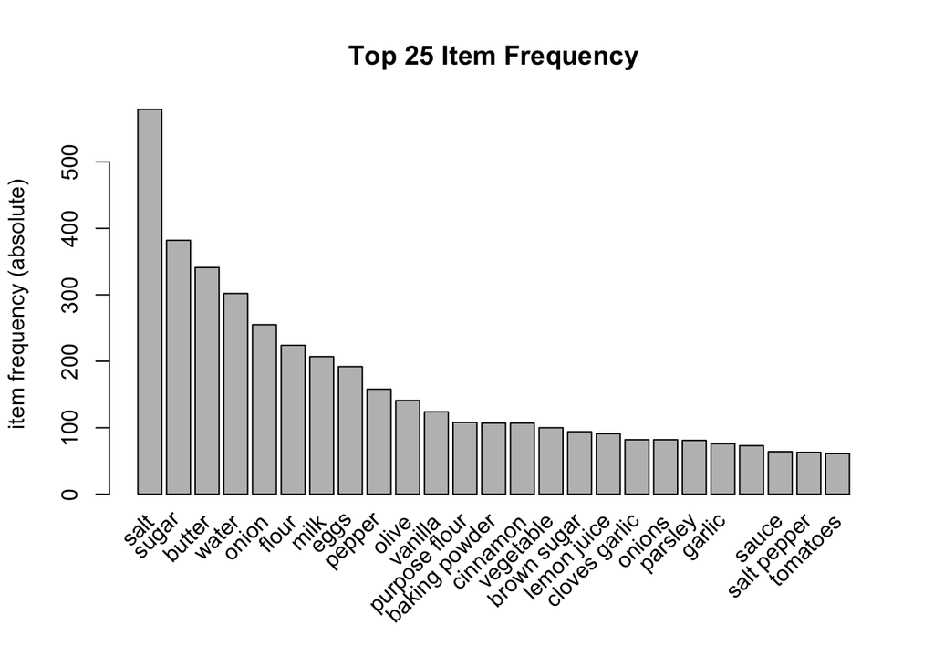

```r
itemFrequencyPlot(trans,topN = 25, type="absolute", main="Top 25 Item Frequency")
```

Vemos que la sal, azúcar y la manteca son los ingredientes que aparecen más.

Usamos el algoritmo “apriori” para encontrar reglas de asociación con un soporte mínimo de 0.001.

```r
reglas <- apriori(trans, parameter = list(supp = 0.001))
```

```
## Apriori
##
## Parameter specification:
##  confidence minval smax arem  aval originalSupport maxtime support minlen
##         0.8    0.1    1 none FALSE            TRUE       5   0.001      1
##  maxlen target  ext
##      10  rules TRUE
##
## Algorithmic control:
##  filter tree heap memopt load sort verbose
##     0.1 TRUE TRUE  FALSE TRUE    2    TRUE
##
## Absolute minimum support count: 1
##
## set item appearances ...[0 item(s)] done [0.00s].
## set transactions ...[3273 item(s), 1480 transaction(s)] done [0.00s].
## sorting and recoding items ... [927 item(s)] done [0.00s].
## creating transaction tree ... done [0.00s].
## checking subsets of size 1 2 3 4 5 6 7 8 9 done [0.01s].
## writing ... [27205 rule(s)] done [0.00s].
## creating S4 object  ... done [0.01s].
```

```r
arules::inspect(sort(reglas, by = "support", decreasing = T)[1:20])
```

```
##      lhs                                    rhs     support    confidence
## [1]  {eggs,vanilla}                      => {sugar} 0.02364865 0.8139535
## [2]  {baking powder,purpose flour}       => {salt}  0.02094595 0.9687500
## [3]  {milk,purpose flour}                => {salt}  0.01959459 0.9354839
## [4]  {eggs,purpose flour}                => {salt}  0.01891892 0.8750000
## [5]  {eggs,salt,vanilla}                 => {sugar} 0.01621622 0.8571429
## [6]  {butter,eggs,vanilla}               => {sugar} 0.01486486 0.8461538
## [7]  {bread flour}                       => {salt}  0.01418919 0.8750000
## [8]  {baking powder,purpose flour,sugar} => {salt}  0.01351351 0.9523810
## [9]  {baking powder,salt,vanilla}        => {sugar} 0.01283784 0.8260870
## [10] {flour,yeast}                       => {salt}  0.01216216 0.8571429
## [11] {purpose flour,vanilla}             => {salt}  0.01216216 0.8181818
## [12] {eggs,purpose flour,sugar}          => {salt}  0.01216216 0.8571429
## [13] {bread flour,sugar}                 => {salt}  0.01148649 0.8947368
## [14] {bread flour,salt}                  => {sugar} 0.01148649 0.8095238
```

[output cut: 27 more lines]

Las 3 reglas con mayor soporte que aparecen son:

- $\{eggs,vanilla\} \Longrightarrow \{sugar\}$
- $\{\mbox{baking powder, purpose flour}\} \Longrightarrow \{salt\}$
- $\{\mbox{milk,purpose flour}\} \Longrightarrow \{salt\}$

## 1.3 Reglas de asociación con recetas de pescado

Vamos a realizar el mismo procedimiento que el caso general pero en el data frame `fish` tenemos las recetas filtradas.

```r
dt_fish <- data.table(fish)
dt_fish <- dt_fish[ , list( ingredientes = unlist( strsplit( ingredientes , "," ) ) ) , by = receta]
dt_fish$ingredientes <- trimws(dt_fish$ingredientes)

dt_fish <- dt_fish %>%
  mutate_all(as.factor)

head(dt_fish)
```

```
##                 receta            ingredientes
## 1: apricot-glazed fish           soak apricots
## 2: apricot-glazed fish                   fresh
## 3: apricot-glazed fish                  butter
## 4: apricot-glazed fish             thick coley
## 5: apricot-glazed fish             salt pepper
## 6: apricot-glazed fish juice grated rind lemon
```

```r
dt_reglas_fish <- dt_fish
dt_reglas_fish$receta <- lapply(dt_reglas_fish$receta, as.numeric)
dt_reglas_fish$receta <- unlist(dt_reglas_fish$receta)

write.csv(dt_reglas_fish, file = "recetas_pescado.csv")

trans_fish <- read.transactions(file = "recetas_pescado.csv",
                                   format = "single",
                                   sep = ",",
                                   header = TRUE,
                                   cols = c("receta", "ingredientes"),
                                   rm.duplicates = TRUE)

summary(trans_fish)
```

```
## transactions as itemMatrix in sparse format with
##  44 rows (elements/itemsets/transactions) and
##  263 columns (items) and a density of 0.03655375
##
## most frequent items:
##  butter    salt   onion   water   flour (Other)
##      15      14      12       8       7     367
##
## element (itemset/transaction) length distribution:
## sizes
##  3  4  5  6  7  8  9 10 11 12 13 14 15 16 17 18 19
##  1  5  2  3  6  3  5  1  5  1  2  2  4  1  1  1  1
##
##    Min. 1st Qu.  Median    Mean 3rd Qu.    Max.
##   3.000   6.750   9.000   9.614  13.000  19.000
##
## includes extended item information - examples:
##     labels
## 1
## 2 allspice
## 3  almonds
##
## includes extended transaction information - examples:
##   transactionID
## 1             1
## 2            10
## 3            11
```

```r
arules::inspect(trans_fish[1:3])
```

```
##     items                                      transactionID
## [1] {butter,
##      fresh,
##      fresh mint sprigs garnish,
##      juice grated rind lemon,
##      potatopepper salad french dressing serve,
##      salt pepper,
##      soak apricots,
##      thick coley}                                         1
## [2] {cloves garlic,
##      fish fillets,
##      fresh parsley,
##      mandarines,
##      olive,
##      onions,
##      piece fresh ginger}                                  10
## [3] {almonds,
##      butter,
##      creammushroom soup,
##      flounder fillets,
##      lemon juice,
##      onion,
##      paprika,
##      rice,
##      rosemary,
##      spinach,
##      water}                                               11
```

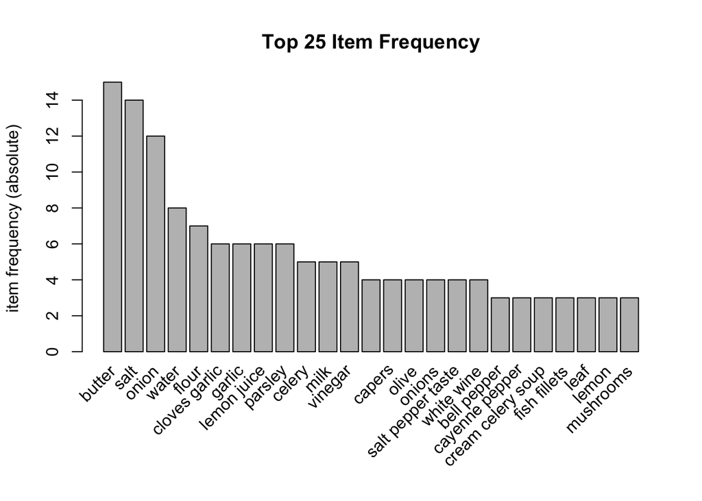

```r
itemFrequencyPlot(trans_fish,topN = 25, type="absolute", main="Top 25 Item Frequency")
```

Los ingredientes que son más frecuentes en este caso son la manteca, la sal, la cebolla, etc.

```r
reglas_fish <- apriori(trans_fish, parameter = list(supp = 0.03))
```

```
## Apriori
##
## Parameter specification:
##  confidence minval smax arem  aval originalSupport maxtime support minlen
##         0.8    0.1    1 none FALSE            TRUE       5    0.03      1
##  maxlen target  ext
##      10  rules TRUE
##
## Algorithmic control:
##  filter tree heap memopt load sort verbose
##     0.1 TRUE TRUE  FALSE TRUE    2    TRUE
##
## Absolute minimum support count: 1
##
## set item appearances ...[0 item(s)] done [0.00s].
## set transactions ...[263 item(s), 44 transaction(s)] done [0.00s].
## sorting and recoding items ... [64 item(s)] done [0.00s].
## creating transaction tree ... done [0.00s].
## checking subsets of size 1 2 3 4 5 done [0.00s].
## writing ... [235 rule(s)] done [0.00s].
## creating S4 object  ... done [0.00s].
```

```r
arules::inspect(sort(reglas_fish, by = "support", decreasing = T)[1:20])
```

```
##      lhs                 rhs                 support    confidence coverage
## [1]  {milk}           => {butter}            0.09090909 0.8        0.11363636
## [2]  {bell pepper}    => {cloves garlic}     0.06818182 1.0        0.06818182
## [3]  {leaf}           => {onion}             0.06818182 1.0        0.06818182
## [4]  {leaf}           => {butter}            0.06818182 1.0        0.06818182
## [5]  {leaf,onion}     => {butter}            0.06818182 1.0        0.06818182
## [6]  {butter,leaf}    => {onion}             0.06818182 1.0        0.06818182
## [7]  {parsley,salt}   => {butter}            0.06818182 1.0        0.06818182
## [8]  {butter,parsley} => {salt}              0.06818182 1.0        0.06818182
## [9]  {flour,salt}     => {butter}            0.06818182 1.0        0.06818182
## [10] {mustard}        => {salt}              0.04545455 1.0        0.04545455
## [11] {black pepper}   => {salt}              0.04545455 1.0        0.04545455
## [12] {wide noodles}   => {cream celery soup} 0.04545455 1.0        0.04545455
## [13] {honey}          => {salt}              0.04545455 1.0        0.04545455
## [14] {cheddar cheese} => {tuna}              0.04545455 1.0        0.04545455
```

[output cut: 27 more lines]

Las reglas de asociación con mayor soporte son:

- $\{milk\} \Longrightarrow \{butter\}$
- $\{\mbox{bell pepper}\} \Longrightarrow \{\mbox{cloves garlic}\}$
- $\{leaf\} \Longrightarrow \{onion\}$

Parece que las recetas de pescado que lleven leche también suelen llevan manteca, las que lleven pimiento morrón llevan dientes de ajo y las que lleven hojas llevan cebolla. Por desconocimiento del campo de la cocina, no sabemos con consistencia si las reglas que hemos obtenido tienen algún sentido.

## 1.4 Reglas de asociación con las recetas picantes

El procedimiento es exactamente idéntico que las recetas de pescado.

```r
dt_spicy <- data.table(spicy)
dt_spicy <- dt_spicy[ , list( ingredientes = unlist( strsplit( ingredientes , "," ) ) ) , by = receta]
dt_spicy$ingredientes <- trimws(dt_spicy$ingredientes)

dt_spicy <- dt_spicy %>%
  mutate_all(as.factor)
```

```r
dt_reglas_spicy <- dt_spicy
dt_reglas_spicy$receta <- lapply(dt_reglas_spicy$receta, as.numeric)
dt_reglas_spicy$receta <- unlist(dt_reglas_spicy$receta)

write.csv(dt_reglas_spicy, file = "recetas_picantes.csv")

trans_spicy <- read.transactions(file = "recetas_picantes.csv",
                                   format = "single",
                                   sep = ",",
                                   header = TRUE,
                                   cols = c("receta", "ingredientes"),
                                   rm.duplicates = TRUE)

summary(trans_spicy)
```

```
## transactions as itemMatrix in sparse format with
##  50 rows (elements/itemsets/transactions) and
##  322 columns (items) and a density of 0.0321118
##
## most frequent items:
##     salt    sugar    water cinnamon    onion  (Other)
##       18       12       11        9        9      458
##
## element (itemset/transaction) length distribution:
## sizes
##  3  4  5  6  7  8  9 10 11 12 13 14 15 16 17
##  1  1  5  2  7  1  3  4  7  2  4  4  5  3  1
##
##    Min. 1st Qu.  Median    Mean 3rd Qu.    Max.
##    3.00    7.00   11.00   10.34   13.75   17.00
##
## includes extended item information - examples:
##           labels
## 1
## 2       allspice
## 3 almond extract
##
## includes extended transaction information - examples:
##   transactionID
## 1             1
## 2            10
## 3            11
```

```r
arules::inspect(trans_spicy[1:3])
```

```
##     items                             transactionID
## [1] {celery,
##      chicken breasts,
##      chili,
##      cilantro,
##      garlic,
##      ginger root,
##      pasta,
##      peanut,
##      peanuts,
##      rice vinegar,
##      salt,
##      sauce,
##      seasame seeds,
##      sesame,
##      snow peas,
##      sugar,
##      water}                                      1
## [2] {cinnamon,
##      crystallized ginger,
##      dark,
##      fresh lemon juice,
##      golden delicious,
##      honey,
##      packed brown sugar,
##      stick butter,
##      walnuts}                                    10
## [3] {bell pepper,
##      black pepper,
##      chicken breast,
##      chicken broth,
##      cloves garlic,
##      cooking,
##      fully smoked sausage,
##      green onions,
##      lbshrimp,
##      pepper,
##      seasoning salt,
##      tabasco sauce,
##      tomatoes,
##      uncle bens longgrain white rice,
##      white onion}                                11
```

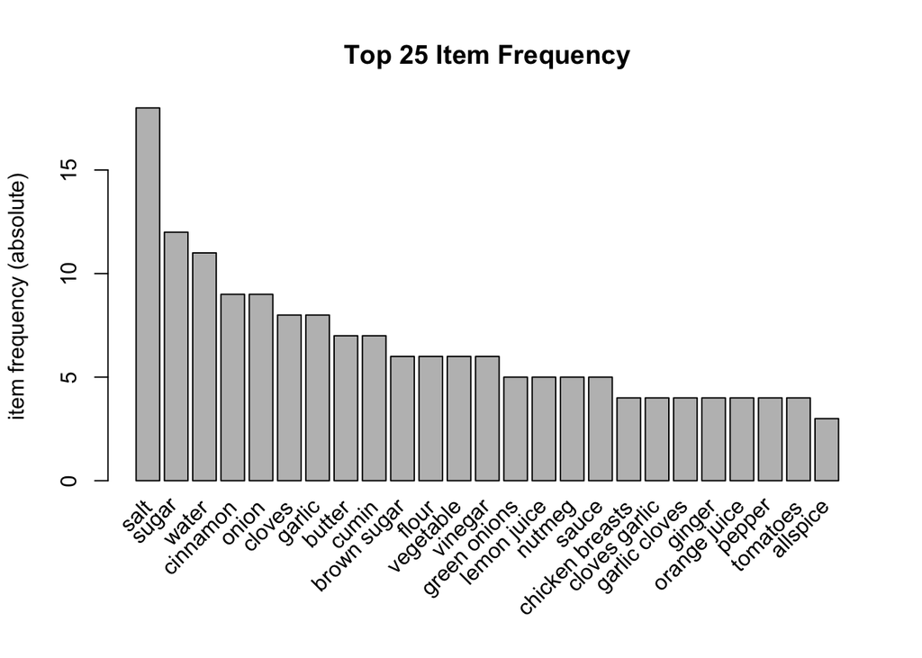

```r
itemFrequencyPlot(trans_spicy,topN = 25, type="absolute", main="Top 25 Item Frequency")
```

En este caso la sal, el azúcar y el agua son los ingredientes más frecuentes.

```r
reglas_spicy <- apriori(trans_spicy, parameter = list(supp = 0.03))
```

```
## Apriori
##
## Parameter specification:
##  confidence minval smax arem  aval originalSupport maxtime support minlen
##         0.8    0.1    1 none FALSE            TRUE       5    0.03      1
##  maxlen target  ext
##      10  rules TRUE
##
## Algorithmic control:
##  filter tree heap memopt load sort verbose
##     0.1 TRUE TRUE  FALSE TRUE    2    TRUE
##
## Absolute minimum support count: 1
##
## set item appearances ...[0 item(s)] done [0.00s].
## set transactions ...[322 item(s), 50 transaction(s)] done [0.00s].
## sorting and recoding items ... [66 item(s)] done [0.00s].
## creating transaction tree ... done [0.00s].
## checking subsets of size 1 2 3 4 5 done [0.00s].
## writing ... [269 rule(s)] done [0.00s].
## creating S4 object  ... done [0.00s].
```

```r
arules::inspect(sort(reglas_spicy, by = "support", decreasing = T)[1:20])
```

```
##      lhs                       rhs              support confidence coverage
## [1]  {flour}                => {salt}           0.10    0.8333333  0.12
## [2]  {baking powder}        => {sugar}          0.06    1.0000000  0.06
## [3]  {eggs}                 => {sugar}          0.06    1.0000000  0.06
## [4]  {allspice}             => {cinnamon}       0.06    1.0000000  0.06
## [5]  {milk}                 => {cloves}         0.06    1.0000000  0.06
## [6]  {milk}                 => {cinnamon}       0.06    1.0000000  0.06
## [7]  {sesame}               => {sugar}          0.06    1.0000000  0.06
## [8]  {sesame}               => {water}          0.06    1.0000000  0.06
## [9]  {ginger root}          => {water}          0.06    1.0000000  0.06
## [10] {cloves,milk}          => {cinnamon}       0.06    1.0000000  0.06
## [11] {cinnamon,milk}        => {cloves}         0.06    1.0000000  0.06
## [12] {sesame,sugar}         => {water}          0.06    1.0000000  0.06
## [13] {sesame,water}         => {sugar}          0.06    1.0000000  0.06
## [14] {cloves,sugar}         => {cinnamon}       0.06    1.0000000  0.06
```

[output cut: 27 more lines]

Las reglas de asociación con mayor soporte son:

- $\{flour\} \Longrightarrow \{salt\}$
- $\{\mbox{baking powder}\} \Longrightarrow \{\mbox{sugar}\}$
- $\{eggs\} \Longrightarrow \{sugar\}$

Igual que las recetas de pescado, por desconocimiento no podemos asegurar que estas reglas de asociación tengan algún sentido real.

# 2 Detección de anomalías

En este apartado vamos a emplear los métodos de DBSCAN y Expectation Maximization para detectar puntos outliers dentro de nuestro conjunto de datos. El data set en cuestión se trata de datos relacionados con el cáncer de mama en Wisconsin, USA. Procedemos a leer los datos y asignarles los nombres correspondientes a cada columna.

```r
bc <- read.csv("breast-cancer-wisconsin.data", header = FALSE, sep = ",")

colnames(bc) <- c("ID", "Clump_thickness", "Uniform_cell_size", "Uniform_cell_shape",
                 "Marginal_adhesion", "Single_epithelial_cell_size", "Bare_nuclei",
                 "Bland_chromatin", "Normal_nucleoli", "Mitoses", "Class")
anyNA(bc)
```

```
## [1] FALSE
```

El data frame no tiene valores NA, pero sabemos que en la columna `Bare_nuclei` hay valores que no se han podido recolectar y se les asigna un “?”.

```r
bc <- bc %>%
  filter(Bare_nuclei != "?")

bc_1 <- bc %>%
  select(-1)
```

```r
glimpse(bc_1)
```

```
## Rows: 683
## Columns: 10
## $ Clump_thickness             <int> 5, 5, 3, 6, 4, 8, 1, 2, 2, 4, 1, 2, 5, 1,…
## $ Uniform_cell_size           <int> 1, 4, 1, 8, 1, 10, 1, 1, 1, 2, 1, 1, 3, 1…
## $ Uniform_cell_shape          <int> 1, 4, 1, 8, 1, 10, 1, 2, 1, 1, 1, 1, 3, 1…
## $ Marginal_adhesion           <int> 1, 5, 1, 1, 3, 8, 1, 1, 1, 1, 1, 1, 3, 1,…
## $ Single_epithelial_cell_size <int> 2, 7, 2, 3, 2, 7, 2, 2, 2, 2, 1, 2, 2, 2,…
## $ Bare_nuclei                 <fct> 1, 10, 2, 4, 1, 10, 10, 1, 1, 1, 1, 1, 3,…
## $ Bland_chromatin             <int> 3, 3, 3, 3, 3, 9, 3, 3, 1, 2, 3, 2, 4, 3,…
## $ Normal_nucleoli             <int> 1, 2, 1, 7, 1, 7, 1, 1, 1, 1, 1, 1, 4, 1,…
## $ Mitoses                     <int> 1, 1, 1, 1, 1, 1, 1, 1, 5, 1, 1, 1, 1, 1,…
## $ Class                       <int> 2, 2, 2, 2, 2, 4, 2, 2, 2, 2, 2, 2, 4, 2,…
```

La variable `Class` indica el tipo de cáncer que es: 2 si es benigno y 4 si es maligno.

```r
bc_1$Bare_nuclei <- as.integer(bc$Bare_nuclei)
```

Vemos que todas las variables son numéricas ahora mismo, ya que hemos pasado la variable `Bare_nuclei` a una variable integer.

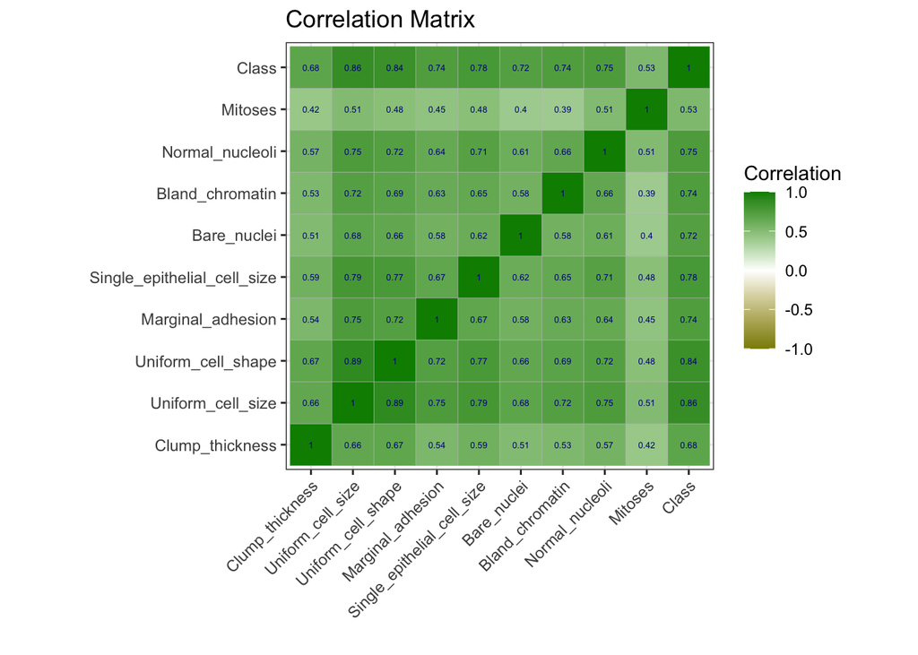

```r
correlation <- cor(bc_1, method = "spearman")

ggcorrplot(correlation, lab = TRUE, lab_size = 1.7, legend.title = "Correlation",
           lab_col = "blue4", colors = c("yellow4", "white", "green4")) +
  theme_bw() +
  theme(axis.text.x = element_text(angle = 45, vjust = 1, hjust=1)) +
  labs(x = "", y = "", title = "Correlation Matrix")
```

Vemos que muchas variables están correlacionadas. Seguimos con este estudio con el siguiente gráfico.

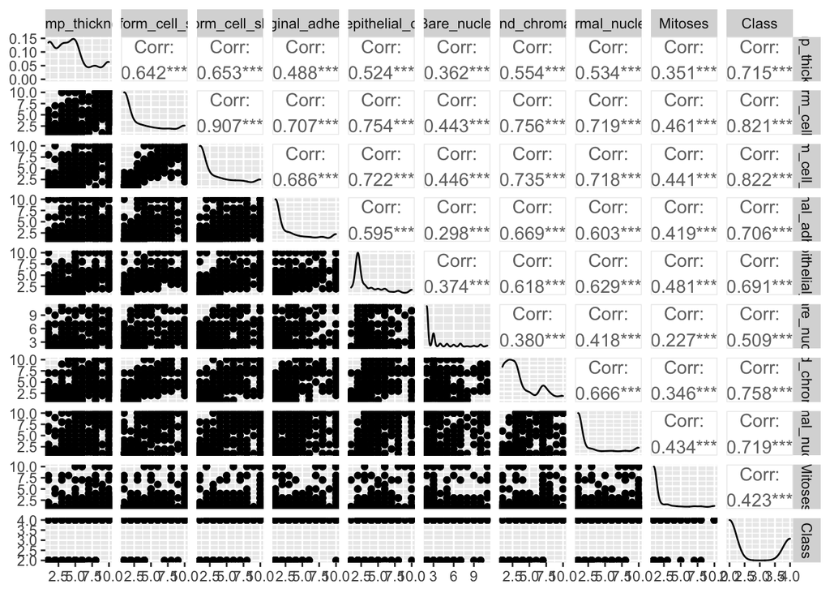

```r
bc_1 %>%
  ggpairs(columns = c("Clump_thickness", "Uniform_cell_size", "Uniform_cell_shape",
                 "Marginal_adhesion", "Single_epithelial_cell_size", "Bare_nuclei",
                 "Bland_chromatin", "Normal_nucleoli", "Mitoses", "Class"),
          columnLabels = c("Clump_thickness", "Uniform_cell_size", "Uniform_cell_shape",
                 "Marginal_adhesion", "Single_epithelial_cell_size", "Bare_nuclei",
                 "Bland_chromatin", "Normal_nucleoli", "Mitoses", "Class"))
```

No se puede observar si hay puntos que puedan ser considerados outliers. Para ello, vamos a realizar un Análisis de Componentes Principales para poder graficar los puntos en un plano.

```r
bc_1 <- bc_1 %>%
  dummy_cols(select_columns = "Class") %>%
  select(-c("Class"))
```

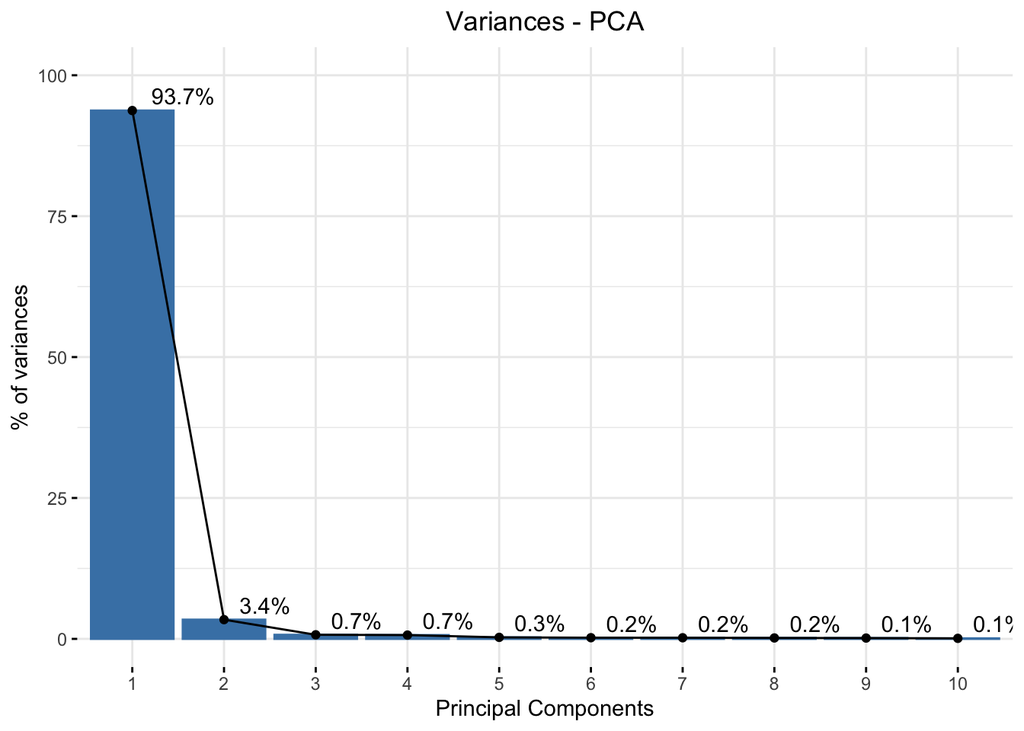

```r
distance_matrix = as.matrix(dist(scale(bc_1)))
pca <- prcomp(distance_matrix)

fviz_eig(pca, addlabels=TRUE, hjust = -0.3) +
  ylim(0, 100) +
  labs(title = "Variances - PCA",
       x = "Principal Components", y = "% of variances") +
  theme(plot.title = element_text(hjust = 0.5))
```

Vemos que la primera componente explica un 93.7% de la varianza y las dos primeras componentes explican un 97.1% de la varianza, lo que supone un porcentaje muy decente.

```r
pca_data <- data.table(pca$x[, 1:2])
pca_data[, id := bc$ID]
pca_data[, class := bc$Class]
pca_data[, row := 1:nrow(bc)]
head(pca_data)
```

```
##          PC1       PC2      id class row
## 1: -39.08313 -2.923182 1000025     2   1
## 2:   5.12373 -7.620094 1002945     2   2
## 3: -37.28878 -1.124588 1015425     2   3
## 4:  29.19902 -3.364807 1016277     2   4
## 5: -38.25095 -3.364363 1017023     2   5
## 6:  92.36971 -4.717917 1017122     4   6
```

Pintamos los puntos con las dos primeras componentes.

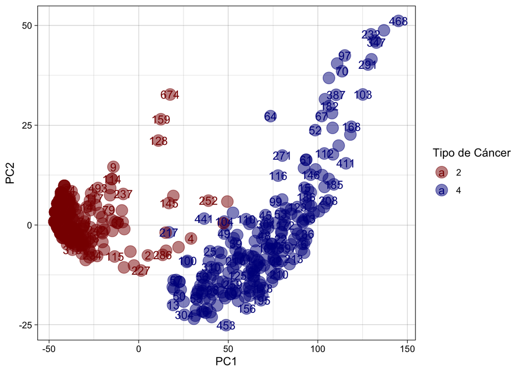

```r
ggplot(pca_data, aes(x = PC1, y = PC2, colour = as.factor(class))) +
  geom_point(size = 5,  alpha = 0.5) +
  geom_text(aes(label = row), check_overlap = TRUE) +
  scale_color_manual("Tipo de Cáncer", values = c("2" = "red4", "4" = "blue4")) +
  theme_linedraw()
```

Podríamos deducir que los puntos de las filas 128, 159, 674 y los puntos que están arriba a la derecha son puntos que están alejados de los dos cúmulos de puntos que nos encontramos en el gráfico.

## 2.1 DBSCAN

Su nombre en inglés significa Density-based spatial clustering of applications with noise y es un algoritmo de clustering de datos. DBSCAN necesita dos parámetros para empezar a funcionar:

- $\epsilon$ como un parámetro especificando el radio de un vecindario respecto a un punto.
- `minPts` es el número mínimo de vecinos necesarios para considerar un punto como un core point y los puntos que no cumplen con el requisito son considerados outliers.

Consideraremos un radio $\epsilon = 2$ y minPts de 3.

```r
dbscan(scale(bc_1), eps = 2, minPts = 3)
```

```
## DBSCAN clustering for 683 objects.
## Parameters: eps = 2, minPts = 3
## The clustering contains 4 cluster(s) and 59 noise points.
##
##   0   1   2   3   4
##  59 437 177   3   7
##
## Available fields: cluster, eps, minPts
```

```r
which(dbscan(scale(bc_1), eps = 2, minPts = 3)$cluster == 0)
```

```
##  [1]   4  15  22  32  42  49  52  53  61  64  67  70  83  84  97  99 104 106 112
## [20] 116 123 128 145 146 155 162 170 182 191 201 216 230 232 247 252 254 257 261
## [39] 271 301 331 344 348 387 420 422 441 473 480 492 555 590 591 594 653 655 676
## [58] 682 683
```

Hay un total de 59 puntos que están en el cluster 0 (puntos que son considerados outliers). Graficamos los clusters.

```r
pca_data[, DClusters := dbscan(scale(bc_1), eps = 2, minPts = 3)$cluster]
pca_data
```

```
##            PC1        PC2      id class row DClusters
##   1: -39.08313  -2.923182 1000025     2   1         1
##   2:   5.12373  -7.620094 1002945     2   2         1
##   3: -37.28878  -1.124588 1015425     2   3         1
##   4:  29.19902  -3.364807 1016277     2   4         0
##   5: -38.25095  -3.364363 1017023     2   5         1
##  ---
## 679: -36.19337   1.401411  776715     2 679         1
## 680: -45.36918   5.356879  841769     2 680         1
## 681:  86.84837  -3.504268  888820     4 681         2
## 682:  63.31354 -11.321235  897471     4 682         0
## 683:  70.22399  -8.696032  897471     4 683         0
```

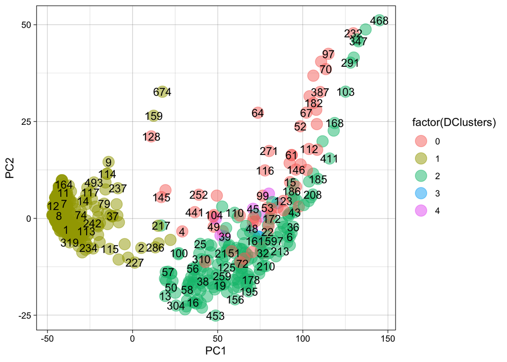

```r
ggplot(pca_data, aes(x = PC1, y = PC2)) +
  geom_point(aes(colour = factor(DClusters)), size = 5, alpha = 0.5)  +
  geom_text(aes(label = row), check_overlap = TRUE) +
  theme_linedraw()
```

```r
bc$Class[which(dbscan(scale(bc_1), eps = 2, minPts = 3)$cluster == 0)]
```

```
##  [1] 2 4 4 4 4 4 4 4 4 4 4 4 4 4 4 4 4 4 4 4 4 2 2 4 4 4 4 4 2 4 4 4 4 4 2 4 4 4
## [39] 4 4 4 4 4 4 2 4 4 4 2 4 4 4 4 4 4 4 4 4 4
```

Vemos que la mayoría de los outliers que salen son de la clase maligna, son casos que tiene sentido que sean clasificados como outliers.

## 2.2 Expectation Maximization

Esta algoritmo de clustering no supervisado trata de encontrar “subespacios similares” basado en su orientación y varianza.

```r
EM <- Mclust(scale(bc_1), G = 5)
EM$classification
```

```
##   [1] 1 1 4 3 4 2 4 4 4 4 4 4 3 4 3 3 4 4 3 1 3 3 4 4 3 4 1 4 4 4 4 3 4 4 4 2 1
##  [38] 3 3 3 2 3 2 4 3 4 4 3 3 3 3 2 3 3 3 3 3 3 3 4 3 3 4 3 4 3 2 4 1 2 4 3 3 4
##  [75] 4 1 4 4 4 4 1 4 2 2 3 3 4 4 4 4 4 4 4 4 4 1 2 2 3 3 4 3 2 3 3 2 4 3 4 3 3
## [112] 3 4 4 1 2 4 4 4 1 2 3 3 4 3 4 3 4 1 4 2 4 4 1 4 4 4 4 4 3 4 4 3 4 1 2 4 3
## [149] 3 4 4 3 4 4 2 3 4 4 4 1 2 2 4 4 4 4 4 2 3 2 4 2 4 3 4 4 1 3 3 4 3 2 3 4 2
## [186] 2 1 4 4 4 3 1 4 4 3 3 4 1 4 2 3 4 4 1 2 3 4 2 2 3 4 4 2 1 4 3 3 3 3 4 3 3
## [223] 4 2 3 3 1 3 1 2 2 2 3 1 4 4 4 4 1 2 3 1 4 3 1 2 3 3 4 4 4 3 3 2 3 3 2 1 3
## [260] 3 2 4 3 1 3 3 4 4 4 4 3 4 4 3 3 3 2 2 4 3 2 4 4 3 3 1 1 3 3 4 2 4 3 3 4 4
## [297] 2 1 4 4 3 4 4 3 3 4 3 3 4 3 4 4 3 4 3 3 3 1 1 3 3 4 3 4 4 3 3 4 4 4 2 4 1
## [334] 4 3 3 1 4 1 2 4 4 3 2 2 3 2 3 4 1 4 4 2 2 4 4 1 4 4 1 4 4 4 4 4 1 4 3 4 4
## [371] 4 4 3 1 4 1 4 3 4 4 4 4 4 4 4 4 2 4 1 4 4 4 4 4 4 4 4 2 1 3 1 3 4 1 4 4 2
## [408] 1 1 4 2 1 3 4 4 4 1 1 4 3 3 3 4 4 1 3 1 4 4 1 4 4 1 4 2 4 1 4 3 4 3 3 2 1
## [445] 1 1 4 1 4 4 2 3 3 4 4 4 1 1 4 1 4 4 4 1 3 4 1 2 3 1 4 4 2 3 3 4 3 4 2 1 4
## [482] 4 4 4 4 1 4 4 4 4 4 2 4 1 4 4 1 1 4 3 3 4 4 4 3 4 4 3 3 4 4 4 4 1 4 3 4 4
## [519] 4 4 4 1 1 4 1 1 4 1 4 4 1 2 4 4 3 4 4 4 1 4 1 1 1 4 1 1 1 4 4 4 2 4 1 3 3
## [556] 3 3 4 4 3 1 1 4 4 4 1 3 3 4 1 4 2 1 3 1 3 3 3 1 3 1 4 1 4 1 4 4 4 3 3 3 4
## [593] 4 2 1 3 2 2 4 4 4 4 4 1 4 1 1 4 1 4 3 4 4 4 1 1 4 3 4 4 2 1 4 1 4 4 4 4 4
## [630] 4 4 4 2 4 4 4 1 4 4 4 1 1 3 4 4 4 4 4 4 4 1 4 3 2 3 4 4 1 4 4 4 1 4 4 2 2
## [667] 1 4 4 4 4 4 4 4 4 3 4 4 4 4 2 3 3
```

```r
pca_data[, EMClusters := EM$classification]
head(pca_data)
```

```
##          PC1       PC2      id class row DClusters EMClusters
## 1: -39.08313 -2.923182 1000025     2   1         1          1
## 2:   5.12373 -7.620094 1002945     2   2         1          1
## 3: -37.28878 -1.124588 1015425     2   3         1          4
## 4:  29.19902 -3.364807 1016277     2   4         0          3
## 5: -38.25095 -3.364363 1017023     2   5         1          4
## 6:  92.36971 -4.717917 1017122     4   6         2          2
```

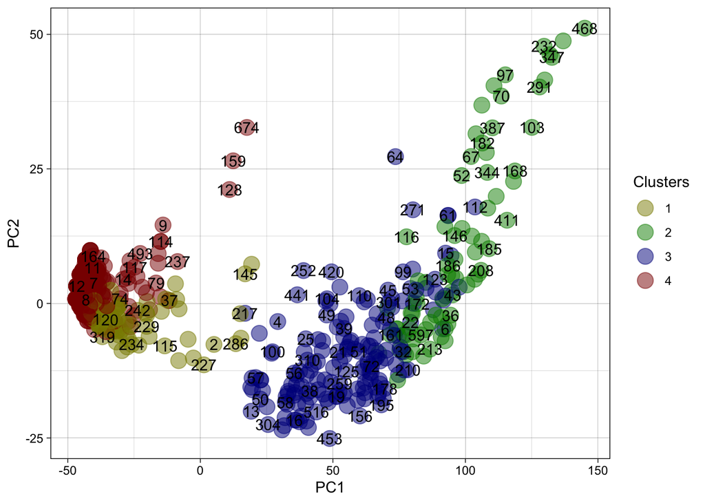

```r
ggplot(pca_data, aes(x = PC1, y = PC2)) +
  geom_point(aes(colour = factor(EMClusters)), size = 5, alpha = 0.5) +
  scale_color_manual("Clusters", values = c("1" = "yellow4", "2" = "green4", "3" = "blue4",
                                            "4" = "red4")) +
  geom_text(aes(label = row), check_overlap = TRUE) +
  theme_linedraw()
```

Vemos ahora que el cluster que puede ser considerado cluster de outliers es el 2.

```r
which(EM$classification == 2)
```

```
##  [1]   6  36  41  43  52  67  70  83  84  97  98 103 106 116 121 131 146 155 161
## [20] 162 168 170 172 182 185 186 200 205 208 209 213 224 230 231 232 240 246 254
## [39] 257 261 277 278 281 291 297 331 340 344 345 347 353 354 387 398 407 411 435
## [58] 443 451 468 473 479 492 532 551 572 594 597 598 621 633 654 665 666 681
```

```r
bc[which(EM$classification == 2), 11]
```

```
##  [1] 4 4 4 4 4 4 4 4 4 4 4 4 4 4 4 4 4 4 4 4 4 4 4 4 4 4 4 4 4 4 4 4 4 4 4 4 4 4
## [39] 4 4 4 4 4 4 4 4 4 4 4 4 4 4 4 4 4 4 4 4 4 4 4 4 4 4 4 4 4 4 4 4 4 4 4 4 4
```